# Types Without Taxa

A Covariance-Matched-Null Multiverse Test of Categorical versus Continuous Personality Structure

Author

Miura Meng

Published

July 11, 2026

Abstract

A clustering method applied to personality data will return some number of “types” whether or not real types exist, which makes the familiar announcement that a dataset contains, say, four personality types hard to read: the number may describe people, or only the method. This paper offers a way to separate the two and applies it to the personality case. I compare each of three large public datasets (roughly one million respondents, across the IPIP-NEO-120, an IPIP Big-Five inventory, and the IPIP-HEXACO) against a matched null: a synthetic population built to reproduce the data’s trait distributions and full correlation structure exactly while containing no types by construction. The comparison runs across all fourteen covariance parameterizations a standard Gaussian mixture model can take, and a taxometric analysis provides an independent second reading. The full procedure was preregistered and run on held-out data. The number of types selected ranges from one to ten as a function of the covariance assumption alone; by the preregistered statistic it never exceeds what the typeless null produces; and no trait reaches a categorical threshold. The real data depart from the null only in higher-order structure, without acquiring types or turning categorical. Dimensional structure in personality is already well established; the contribution here is the test: a documented, reusable procedure to which any future claim of N types, from any clustering pipeline, can be held.

Keywords

mixture models, matched null, multiverse analysis, taxometrics, categorical versus continuous

# 1 Introduction

Few ideas about personality are as easy to like as the idea that people come in kinds. We call each other introverts and extraverts as though naming two species; we sort ourselves into four-letter codes; and every few years a study announces that the data, left to themselves, fall into a handful of personality types. One widely cited paper found four (Gerlach et al., 2018). The appeal is no mystery. A type is something you can hold in your head; a position in a five- or six-dimensional space is not.

But a clustering method will find types whether or not any are there. Give a mixture model a single smooth cloud of data and it still reports two or three or ten groups, because each added group trims the fit a little and the selection rule takes the trade, so a clean partition on its own establishes little; the question is whether its groups mark anything beyond the shape the data already had.

On personality itself, the argument is largely over. Taxometric[^1] and structural studies have looked for categories in trait data for years and kept finding gradients instead (Haslam et al., 2012; Haslam et al., 2020). I do not aim to reopen that. What the settled view still lacks is a way to check a specific claim, this dataset and these respondents and this many types, against a null that means something, and a sense of how much the claim depends on choices made before any result is in view.

Past attempts to impose that discipline fall short in ways worth naming. The best-known typology study tested its clusters against data with all the associations shuffled out (Gerlach et al., 2018), but data with no correlations is a low bar, and almost anything real clears it. A later comment made the same criticism but did not supply the null it called for (Katahira et al., 2020). Taxometrics asks the categorical-versus-continuous question directly (Meehl, 1995; Ruscio et al., 2006), but it works from a fixed set of indicators; it does not say how many clusters there are, or how that number moves when the model changes.

My approach has three parts, each drawn from an established literature; what is new is the null they are assembled around and the question that assembly makes testable. The null is a Gaussian copula. It keeps every trait’s distribution and the whole covariance matrix and scrambles only what is left, the higher-order dependence, so a cluster counts as real only if it survives a world that already shares the data’s margins and correlations. This is the constructed null the earlier comment called for. Rather than report a single number, I run the same test across all fourteen covariance parameterizations of the mixture model and report the full spread of answers in place of any single preferred one. And I bring in taxometrics as an independent check, so the verdict does not rest on one method’s assumptions. All of it is aimed at the personality-types question, across three datasets. The test is also held to the standard it imposes: positive controls show that it detects types deliberately built into synthetic data, and calibration on typeless data, Gaussian and skewed alike, shows that it stays quiet when there is nothing to find.

The three datasets return the same answer. Change the covariance assumption and the number of types walks from one to ten. Hold the rest fixed and, by the measure I committed to in advance, that number is no different from what the typeless null gives. No trait crosses the taxometric line. None of that is new about personality. What it shows is that the test works, and that the next typology has something to answer to.

# 2 Background

## 2.1 A cluster solution settles nothing on its own

Sorting people into kinds recurs in quantitative psychology under one label after another: clinical subtypes, learner profiles, market segments, data-driven personality types. Each time the trouble is the same. Clustering and mixture methods exist to partition; give them continuous data and they partition it anyway, and a selection criterion will almost always prefer more than one piece. That mixture models over-extract components when continuous data depart from normality is well established (Bauer & Curran, 2003). So “the data support k clusters” quietly mixes a fact about people with a fact about the procedure, and the procedure on its own never says what a world with no types would have produced under the same treatment.

## 2.2 What is already settled

On the substance, the verdict is in: two meta-analyses of the taxometric literature find trait structure dimensional, not categorical (Haslam et al., 2012; Haslam et al., 2020). A parallel person-centered tradition has repeatedly recovered three replicable prototypes, the resilient, overcontrolled, and undercontrolled types (Asendorpf et al., 2001; Robins et al., 1996), and their standing has been contested on exactly the ground at issue here: what a recovered cluster establishes about the population. What that settled verdict still lacks is a tool, one that turns a particular cluster-count claim into something that can fail, and shows how much it leans on choices no one inspects.

## 2.3 The choice of null

An apparent grouping is “real” only against a null that says what real means here. Shuffle every association out of the data (Gerlach et al., 2018) and you have set the bar on the floor; the correlations alone will clear it. Katahira et al. (2020) saw this but stopped at the diagnosis. Nor do the standard referees for a cluster count answer it. The gap statistic compares the observed clustering to a reference with no dependence at all, a uniform distribution over a box (Tibshirani et al., 2001), which correlated data clear as easily as the shuffled null above; the bootstrap likelihood-ratio test (McLachlan, 1987) asks whether $k+1$ components fit better than $k$ within a chosen family, not whether the data’s own margins and covariance already produce the clustering; SigClust tests whether a two-group split is significant against a single Gaussian null (Liu et al., 2008), whose Gaussian margins are the very assumption the over-extraction problem violates, and which speaks to whether any clustering exists rather than to the selected count; and methods that merge components after fitting (Hennig, 2010) repair a solution rather than test one. The cure is borrowed from elsewhere, from the surrogate-data and matched-null traditions[^2] of nonlinear time series, network neuroscience, and ecology, where you fix everything innocent about a dataset and randomize only the thing in question. For a claim about clusters the copula null is the natural choice: keep the margins, keep the covariance, and let only higher-order dependence vary, so any extra clustering has to come from structure the null cannot hold.

## 2.4 A second opinion

Taxometrics reaches the same question by a different road, asking whether the covariation among a construct’s indicators looks more like one dimension or two latent groups (Meehl, 1995; Ruscio et al., 2006). The Comparison Curve Fit Index scores the observed curves against curves simulated from frankly dimensional and frankly categorical data. Because its assumptions are not a mixture model’s, it makes a useful outside check, though it works on a fixed indicator set and says nothing about how many clusters there are.

## 2.5 Reporting the spread, not a point

That a result can hang on a defensible choice is the premise of multiverse and specification-curve analysis (Simonsohn et al., 2020; Steegen et al., 2016), with a longer root in the sensitivity arguments of econometrics (Leamer, 1983). The honest move is to run the reasonable specifications and show the distribution instead of defending one. For the number of types, the choice that matters is the mixture model’s covariance assumption, which I vary in full; the matched null then says where, on that spread, a typeless world would have landed.

# 3 Method

## 3.1 Transparency and Openness

Everything that could push the result toward “types” or “no types” was fixed before I saw the test data. Before opening the held-out data I registered the decision rule and the specification grid (OSF preregistration osf.io/2ekcg; analysis seed 20260620), and what follows reports every dataset, every covariance model, and the whole rule, with nothing added or dropped once the hold-out was in view. The three datasets are public and anonymized, and their sources are documented in the project repository alongside the complete analysis code; the study is a secondary analysis of these data and involved no new data collection. The University of Pennsylvania Institutional Review Board determined that it did not require review. I report how the analysis subsamples were determined, all data exclusions, and all measures, and I follow the Journal Article Reporting Standards.

## 3.2 Data

I reanalyze three large public datasets, each already scored to traits and, where the instrument allows, facets: the IPIP-NEO-120 (Johnson, 2014) (410,376 respondents; five domains, thirty facets); an IPIP fifty-item Big-Five set (Goldberg, 1999) (603,322; five domains, no facets defined); and the IPIP-HEXACO (22,734; six domains, twenty-four facets), an item-pool implementation of the HEXACO model (Lee & Ashton, 2004). Three instruments rather than one, so that a verdict has to repeat across measurement systems instead of surviving in a single one.

I split each dataset in half (seed 20260620) into an exploratory and a confirmatory part, and sealed the confirmatory part before fitting anything reported here. For the NEO-120 and the fifty-item set the held-out respondents are almost all unseen, about 95 to 97 percent; HEXACO is small enough that the halves overlap, with about 88 percent of its hold-out also in the exploratory split, so I treat it as a robustness check rather than a clean confirmation. Every model was fit to a random subsample of the held-out part, 8,000 cases at the domain level and 5,000 at the facet level. One housekeeping point matters later: mixtures tend to select more components as the sample grows, so I always compare the real data and its null at the same sample size. The dependence is steep in these data: at the domain level the median selected count rises from about 2.5 at n = 2,000 to the grid ceiling at n = 32,000 (Table S6).

## 3.3 The covariance multiverse

A mixture model asks how many components best describe a cloud of points, and the answer turns on a setting most studies fix without comment: the shape the components are allowed to take. I model each dataset as a Gaussian mixture and let “types” mean the components a BIC selection keeps. mclust (Scrucca et al., 2016) offers fourteen ways to constrain a component’s covariance, in volume, shape, and orientation, running from the spherical (EII, VII) through the diagonal (EEI, VEI, EVI, VVI) to the fully ellipsoidal (EEE through VVV).[^3] For each, I fit one to ten components and record the number BIC prefers. The registered grid also carries ICL as an alternative selection criterion; because ICL adds an entropy penalty that favors well-separated solutions, it bears on types directly, and its arm is reported in the supplement (Table S4). The fourteen answers, taken together, are the specification curve: the number of types found as a function of an assumption that carries no meaning about people.

## 3.4 The Gaussian-copula matched null

To tell a real clustering from one that any dataset of this shape would show, I compare it against a Gaussian-copula null:[^4] a twin of the data with the same margins and the same correlations, but no types built in. The null holds those two things fixed and frees the rest, replacing all higher-order dependence with plain Gaussian dependence, so by construction it contains no latent types. The Gaussian copula is the minimal null for the role, not the most faithful one, and minimality is what the test needs. Its dependence is exhausted by the correlation matrix, so every higher-order dependency in the real data must come from the data rather than the null. A richer copula would defeat the purpose: a t copula adds tail dependence, and a vine copula can fit almost any dependence structure at all, so using either as the null would absorb into it the very structure the test is meant to detect, leaving a real-equals-null result that shows only that the null was too strong to say anything about types.

Pictured as a three-story building, the data hold their marginals, each variable’s histogram, on the ground floor, and their pairwise correlations on the second; everything from the third floor up is higher-order dependence, where any latent types would live, since groups within a dataset show up as conditional dependencies beyond the linear correlation. The copula null rebuilds the ground floor and the second floor exactly as in the real data and leaves every floor above empty: once the correlation matrix is fixed, its Gaussian dependence adds no further joint structure. If clustering finds as many components in a building whose upper floors are empty as it does in the real data, those components were never on the upper floors of the real data either; they were the shape of the lower two all along.

The construction is a single rank transformation:

> **Algorithm 1. Gaussian-copula matched null.**

> *Input:* a real $n \times p$ subsample $\mathbf{X}$.
> 1. Take the correlation matrix $\mathbf{C} = \operatorname{cor}(\mathbf{X})$ and its Cholesky factor $\mathbf{L}$ (adding a $10^{-6}$ ridge to the diagonal if $\mathbf{C}$ is not positive definite).
> 2. Draw $\mathbf{Z}$, an $n \times p$ matrix of independent standard-normal values, and set $\mathbf{Y} = \mathbf{Z}\mathbf{L}$, so that $\mathbf{Y}$ carries the same correlations as $\mathbf{X}$.
> 3. For each variable $j$, replace column $j$ of $\mathbf{Y}$ with the sorted real values of $X_{j}$, laid down in the rank order of $Y_{j}$.

> *Output:* $\mathbf{X}^{\ast}$, whose every marginal matches $\mathbf{X}$ exactly, whose covariance matches to within sampling error (the largest correlation it misses is about 0.009), whose dependence is Gaussian, and which has no clustering built in.

Step 3 is the rank reordering of Iman & Conover (1982); it matches the normal-scores rank correlation exactly, so the Pearson covariance is reproduced only up to sampling error, which the 0.009 figure above verifies directly.

The null, then, is a synthetic dataset whose every histogram and every correlation match the real one but which is guaranteed to contain no real groups; if it produces as many types as the real data, the types were the shape of the data, not a feature of the people. I drew two hundred such nulls for each dataset, each at the matched sample size, and ran the full fourteen-model specification curve on every one. The registration specified 1,000 null replicates; the cost of the fourteen-model grid per replicate made that impractical, and two hundred were drawn instead, a reported deviation. The resulting Monte Carlo error is small: bootstrap standard errors for the null interval endpoints run from 0.07 to 0.31 components, and no verdict in Table 1 changes when an endpoint is moved by twice its standard error.

## 3.5 The matched-null tests

The matched null answers two questions: whether the data carry any structure beyond their margins and covariance at all, and whether that structure raises the number of types. One statistic is read against the null for each. The first: $\Delta$BIC, the BIC of the best of the fourteen models minus the one-component BIC,[^5] is required to exceed the 95th percentile of the null’s $\Delta$BIC (call this H1). The second is the registered test of how many types there are: the real median count across the fourteen models is required to fall inside the null’s 95 percent interval for the count to be judged no larger than a typeless population’s (H3); equivalently, a one-sided Monte Carlo p-value gives the proportion of null draws whose median matches or exceeds the real median. The median is less sensitive than the mean to the few parameterizations censored at the ten-component ceiling; the mean is reported alongside it in the Results, and the choice between them is taken up in the Discussion. H1 is a low bar, certifying only that the data are not Gaussian, and serves as a precondition; H3 is the test that bears on types. The registration also defines H2: not a further statistical test but a composite verdict that the structure is continuous, requiring four criteria to hold jointly; it is evaluated under the pre-registered decision rule below, so the labels here follow the registration.

## 3.6 Taxometric analysis

As a second opinion that does not rest on a mixture model’s assumptions, I submit each trait’s facets (six per NEO-120 trait, four per HEXACO trait) to the two taxometric procedures named in the registration, MAMBAC and MAXEIG,[^6] through RTaxometrics (Ruscio, 2023). These procedures require several indicators of one construct, so a single domain score cannot be used on its own and the facets supply the indicators trait by trait. The Comparison Curve Fit Index (CCFI) scores the observed curves against curves simulated from explicitly dimensional and explicitly categorical comparison data, returning a number between zero and one: below .45 reads dimensional, above .55 categorical, with an ambiguous band between (Ruscio et al., 2006). I report each trait’s CCFI as the average of the two registered procedures and keep the spread between them in view; the L-Mode curve, which the routine also returns, is reported as a supplementary read. The fifty-item set has no facets, so this part covers only the NEO-120 and HEXACO; item-level indicators were not substituted, since single Likert items are too coarse and unreliable to serve as taxometric indicators and the registration specified facet composites.

## 3.7 Positive-control simulations

A null finding means nothing unless the test can detect types when they are genuinely present, so I ran the whole procedure on synthetic data with known structure, in two regimes (five variables, 4,000 cases, forty nulls per setting). In the dependence regime, two components share identical standard-normal margins on every variable and differ only in the sign of their within-pair correlations, so the type signal lives entirely in the joint structure and nothing leaks into the histograms; the within-component correlation ranges over 0, .30, .50, .70, and .85. In the separation regime, components differ in their means, so the separation does enter the histograms; the centroid separation ranges from 0 to 3 standard deviations. For each setting I ran the specification curve on the synthetic data and on forty copula nulls of it, and counted a detection when the real median count exceeds the null’s 97.5th percentile.

Two extensions place the procedure among existing referees and check its calibration. First, on the same synthetic datasets I ran two standard competitors: the gap statistic (Tibshirani et al., 2001), with a k-means base, fifty reference draws, and the principal-component-aligned uniform reference, and the bootstrap likelihood-ratio test (McLachlan, 1987) under the correctly specified VVV family with ninety-nine bootstrap draws (Table S5). Second, I calibrated the false-positive rate on typeless data: one hundred datasets drawn from a Gaussian with the correlation matrix of the real NEO-120 domains, and one hundred more with the same Gaussian copula but skewed margins (chi-square, beta, and squared-uniform transforms), the regime in which mixtures over-extract (Bauer & Curran, 2003). Each dataset was compared with forty of its own copula nulls at n = 2,000, with the same 97.5th-percentile criterion (Table S7).

## 3.8 The pre-registered decision rule

The rule was set before the hold-out opened; the full text is in the registration. An instrument is credited with real structure only if it clears H1. I then call its structure continuous only if four things hold together: mean within-trait CCFI under .45 with no trait at .55 or above, in both instrument families; fewer than half of respondents confidently placed in any one component, at a posterior above .8; the first split, from one component to two, carrying more than three-quarters of the total BIC gain; and the median-count test H3. The opposite verdict, real types, needs the opposite signs: a CCFI at .55 or above that repeats across instruments, a clear BIC minimum with gaps between component centers, most respondents confidently placed, and a count that holds steady across datasets. The NEO-120 and the fifty-item set are the confirmatory pair and have to agree; HEXACO is robustness only.

For the record, the remaining statistics are these. The count summarized across models is the median of the fourteen; the first-split share is the two-component gain over the total gain, both measured on the best-of-fourteen envelope; and the confident-assignment share is the fraction of respondents whose top posterior exceeds .8 under the selected solution. The thresholds themselves (.8, one-half, three-quarters) are conventions fixed at registration rather than derived quantities; Table 2 reports the underlying proportions, so any alternative threshold can be applied directly.

## 3.9 Software

R 4.5.2 (R Core Team, 2025), with mclust 6.1.2 (Scrucca et al., 2016) for the mixtures, RTaxometrics 3.2.1 (Ruscio, 2023) for the CCFI, and cluster 2.1.8 for the gap statistic; seed 20260620 throughout. The procedure is implemented in an R package, matchednull, whose functions, null construction, the count test, and the signature checks, take any data matrix and any clustering routine; it is publicly available, and a release on CRAN is planned. Data, code, and the registration are public.

# 4 Results

## 4.1 What the reported count depends on

A study that reports “four personality types” is reporting a number, and that number reflects both the data and the analyst’s modeling choices. Before introducing any null, I asked how much it owes to each: holding the data fixed and varying only the covariance parameterization of the mixture model, how far does the selected count move?

It moves across most of the available range. I fit each dataset under all fourteen of mclust’s covariance parameterizations and recorded the number of components BIC selected in each (Figure 1; the full per-parameterization counts are in Table S1). The fourteen counts did not converge in any of the five analyses. The selected number ran from two to ten in the NEO-120 domains and across the full grid, one to ten, in its thirty facets, with comparable spreads in the remaining datasets. A single modeling choice that encodes no claim about respondents thus shifts the reported count across nearly the entire range a study might report.

The spread is also patterned by covariance family (Figure 1). The spherical and diagonal parameterizations, which constrain components to simple shapes, generally selected at or near the ten-component ceiling; the fully ellipsoidal parameterizations, which permit each component an arbitrary shape, selected far fewer, in several cases one or two. A flexible component covariance can accommodate the continuous, correlated shape of a real data cloud within a single component, whereas a constrained one approximates that shape by adding components. The selected count therefore reflects the covariance assumption more than any property of the respondents, and that assumption is fixed before the data are examined. Because the grid fits one to ten components, the spherical and diagonal counts are censored at ten and read as lower bounds; the same registered ceiling applies to the null, so the comparison is like for like.

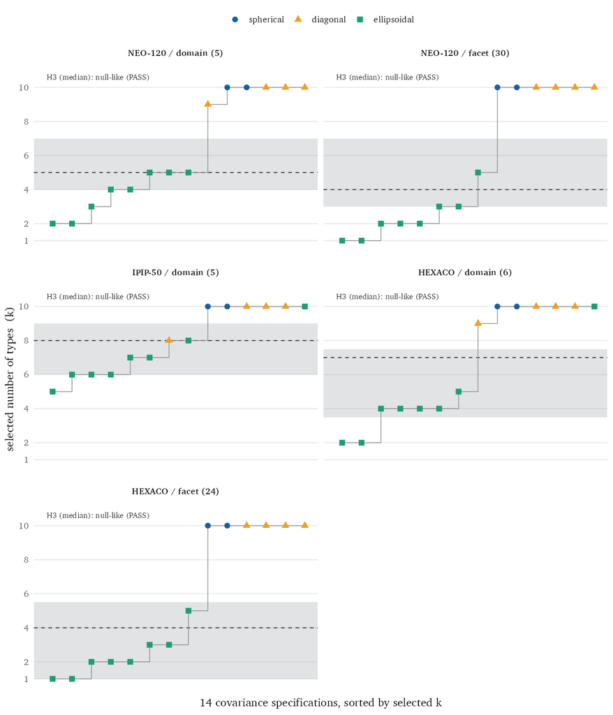

Figure 1: The BIC-selected number of mixture components (“types”) across the fourteen covariance parameterizations, on held-out data at the matched sample size. Each point is one parameterization, colored and shaped by covariance family and sorted by selected count. The grey band marks the 95% interval of the matched-null median count; the dashed line is the real median. A real median inside the band indicates a typical count indistinguishable from data with no latent types.

## 4.2 Whether there is any real structure to explain

An unstable count is not, by itself, evidence of a problem. The data could be genuinely heterogeneous in a way no single count captures. Before testing whether such heterogeneity constitutes types, I first checked whether the data depart at all from the smooth structure their margins and correlations already imply.

This is the role of the matched null. For each dataset I compared the real clustering to the synthetic twin defined in the Method, which preserves every marginal distribution and the full correlation matrix but contains no latent groups, and asked whether the real data cluster more than that twin. They do in all five analyses: the BIC improvement of the best mixture over a single component exceeds the null’s 95th percentile in every case (Table 1, H1).

So the real data carry structure beyond what a jointly Gaussian distribution with the same margins and correlations would produce. But this establishes very little, and it is easy to over-read. The null fixes only the linear dependence, so any departure from joint normality, including skew, mild nonlinearity, or uneven density, is sufficient to exceed it; H1 is a test of non-Gaussianity, not of latent-class structure. Whether the departure takes the specific form of additional types is a separate question, addressed by the two tests that follow.

## 4.3 Whether that structure increases the number of types

The central test concerns the count itself. The real data carry structure the null does not reproduce; the question is whether that structure raises the number of types. Summarizing the fourteen per-model counts requires a single statistic, and the one preregistered for this purpose was their median. The test compares the real median to the distribution of medians the null produces.

In all five analyses the real median falls within the null’s 95% interval (Table 1, H3). In the NEO-120 domains, for example, the real median is five components against a null interval of [4.0, 7.0], so the observed value is unremarkable relative to a typeless population; the same holds in every dataset. As a one-sided test, the real median does not significantly exceed the null in any dataset (Monte Carlo p from .11 to .80, all above .05, smallest for the not-naive HEXACO domains). The structure detected by H1 does not, by this measure, raise the typical number of types above what a population with no latent types yields under the identical procedure. Figure 1 displays the comparison: the real median (dashed line) lies within the null interval (grey band) in every panel.

The mean diverges from the median, and the divergence is informative. Summarized by the mean rather than the median, the count exceeds the null in three of the five datasets. The two summaries differ because the per-model counts are right-skewed: a few covariance parameterizations select at the ten-component ceiling while most select far fewer, which raises the mean but leaves the median unaffected. I preregistered the median and report the mean alongside it. That the verdict can depend on the choice between two routine summaries of the same fourteen values, made after the values are known, is the kind of analytic flexibility this study is designed to expose, and the reason the summary statistic was fixed in advance.

Restricting the count summary to the eight fully ellipsoidal models, the ones these data favor, tightens the comparison with the null. The three confirmatory analyses stay inside the null’s interval, two of them at its upper edge, and both HEXACO analyses fall above it (Table S3). Under this summary the confirmatory data select a slightly higher count than their Gaussian twins, and the excess sits in the best-fitting models.

The restriction drops the six constrained models, which select at or near the ten-component ceiling for the real data and the twins alike. Pinned near the same ceiling, they give the same count for the real data and its twins whatever structure is present, so including them shrinks the gap between real and null toward zero. Removing them lets the ellipsoidal-only summary register a small difference the full set hides.

Whether the confirmatory data support five components or six is a question the count answers; whether those components are categories is answered by the taxometric index and the confident-assignment share, and neither of those changes under the ellipsoidal-only restriction or any other. No trait reaches the categorical range on the CCFI, and no dataset assigns a majority of respondents to a single component with confidence. The registered count statistic stays the fourteen-model median, fixed before the held-out data were opened. The small excess the ellipsoidal-only summary shows is structure of the kind H1 already found: it improves fit without forming discrete groups.

**Table 1.** Real data compared with the matched null, by analysis. H1 holds when the real clustering gain ($\Delta$BIC of the best mixture over a single component) exceeds the null’s 95th percentile; H3 holds when the real median count lies within the null’s 95% interval. Both hold in every analysis.

| Slice | $n$ | Median $k$ | Null 95% (H3) | $\Delta$BIC | Null 95th (H1) |
| --- | --- | --- | --- | --- | --- |
| NEO-120 dom. | 8,000 | 5 | [4.0, 7.0] | 717 | 488 |
| NEO-120 fac. | 5,000 | 4 | [3.0, 7.0] | 4,013 | 1,122 |
| IPIP-50 dom. | 8,000 | 8 | [6.0, 9.0] | 1,369 | 915 |
| HEXACO dom. | 8,000 | 7 | [3.5, 7.5] | 816 | 221 |
| HEXACO fac. | 5,000 | 4 | [1.0, 5.5] | 2,701 | 344 |

## 4.4 Whether the traits are categorical under a different method

The two mixture-based tests share a model family and its assumptions about what constitutes a group. The third component of the analysis applies a method with different assumptions: taxometric analysis. For each trait I submitted its facets to the two preregistered procedures, MAMBAC and MAXEIG, and computed the Comparison Curve Fit Index (CCFI), which compares the observed indicator covariation to data simulated under explicitly dimensional and explicitly categorical models. By the conventional interpretation, a CCFI below .45 indicates dimensional structure and one above .55 categorical structure, with an ambiguous region between (Ruscio et al., 2006). The preregistered statistic for each trait is the mean of the two procedures.

No trait’s registered CCFI reached the categorical threshold (Figure 2). The mean CCFI was .375 across the NEO-120 facets and .430 across the HEXACO facets, both in the dimensional range; the highest single value, for NEO-120 Openness, was .535, within the ambiguous region, followed by HEXACO Honesty-Humility at .520. All eleven registered means fall below .55.

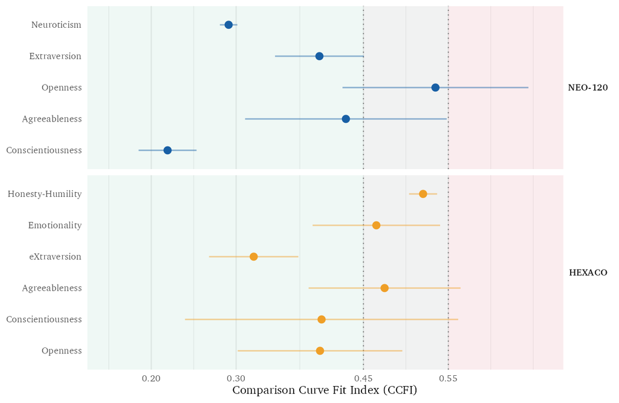

Figure 2: CCFI by trait. Each point is the mean of the two preregistered procedures, MAMBAC and MAXEIG; the segment marks their range. Values below .45 read dimensional, .45 to .55 ambiguous, above .55 categorical. No trait’s registered mean reaches the categorical threshold; the full per-trait values, including the supplementary L-Mode curve, are in Table S2.

## 4.5 Whether the model assigns people to those groups

A further pair of preregistered checks evaluates the selected solution directly, granting for the moment that its components are real and asking whether they behave as latent types would. The first is the confident-assignment share: the proportion of respondents whose maximum posterior probability of component membership exceeds the preregistered threshold of .8. Genuine types would assign most respondents to a single component with high posterior probability. The second is the first-split share: the proportion of the total BIC gain (the improvement of the selected solution over a single component) attributable to the first division, from one component to two. The rationale, fixed in advance, is that partitioning a continuum yields most of its fit improvement at the first split and diminishing returns thereafter, whereas separable types continue to improve fit as components are added.

Both indicators are consistent with continuity (Table 2). The confident-assignment share is below 50% in every dataset, from 10.6% (IPIP-50 domains) to 48.9% (NEO-120 facets). The first-split share exceeds 75% in four of the five datasets, reaching 98.9% in the HEXACO facets; the exception is the fifty-item inventory at 59.4%. Under the selected solutions, most respondents are not assigned to any component with high confidence, and most of the fit improvement is concentrated in a single binary division.

**Table 2.** The BIC-selected mixture solution for each dataset and two preregistered properties of it. Confident assignment: the proportion of respondents with maximum posterior membership probability above .8. First-split share: the proportion of the total BIC gain (selected solution over a single component) contributed by the one-to-two-component division.

| Slice | Model | $k$ | Confident assign. (>.8) | First-split share |
| --- | --- | --- | --- | --- |
| NEO-120 dom. | VEE | 5 | 16.0% | 90.2% |
| NEO-120 fac. | VEE | 5 | 48.9% | 88.7% |
| IPIP-50 dom. | VVE | 8 | 10.6% | 59.4% |
| HEXACO dom. | VVE | 4 | 24.0% | 86.6% |
| HEXACO fac. | VEE | 3 | 46.0% | 98.9% |

## 4.6 Whether the procedure could detect types if present

A null result is informative only if the procedure can detect types when they are present. I therefore assessed its power on synthetic data with known structure, generating two kinds of latent types and passing each through the identical pipeline (Figure 3).

The first kind is defined entirely by dependence. Its two components share an identical marginal distribution on every variable and differ only in the orientation of their correlations, so the grouping is absent from every univariate distribution and present only in the joint structure. The procedure detects this kind, and detection increases with signal strength: as the correlation difference grows, the real median count separates from the null, rising from one to two to nine and ten, while the null median remains at one. This regime is the more relevant one for personality, because a central form of the type hypothesis, types that differ in the configuration of traits rather than in the level of any single trait, would produce structure of this kind.

The second kind defines the procedure’s limit. Here the components differ in their means, so the separation also enters the univariate distributions. At moderate separations the procedure still detects the structure, registering it at mean differences of 1.5 and 2.0 standard deviations. At the largest separation tested, 3.0 standard deviations, it does not: at that point the separation is carried almost entirely by the margins and covariance jointly, which the null preserves by construction, so the null reproduces the same partition without any latent groups having been specified. The limitation is therefore specific to types separated enough to enter the margins and covariance together. The trait margins here show nothing comparable: unimodality tests on the raw scores reject only because summed Likert scales are granular, and after a tie-breaking jitter 64 of the 65 margins retain unimodality (Hartigan & Hartigan, 1985); the null in any case inherits each margin exactly, granularity included, so the present data sit in the regime where the procedure has power.

The procedure is also calibrated, and the competing referees divide cleanly. On one hundred typeless datasets built on the real NEO-120 domain correlation matrix, jointly Gaussian, the registered test fired in none (nominal rate 2.5%). On one hundred more with the same Gaussian copula but skewed margins, the over-extraction regime documented by Bauer & Curran (2003), it again fired in none, while BIC selection reported more than one component in every one of the hundred datasets, 9.7 on average of a possible ten, and the bootstrap likelihood-ratio test did the same in all thirty datasets tested (Table S7). On the positive controls the pattern reverses (Table S5): the gap statistic never detects the dependence-defined types at any signal strength, while the bootstrap test detects and counts them where its parametric family is exactly right. Each referee fails somewhere. The matched-null test is the one that both detects types living in the dependence and stays quiet on typeless data of either kind; its own boundary, separation strong enough to enter the margins and covariance, is the one described above.

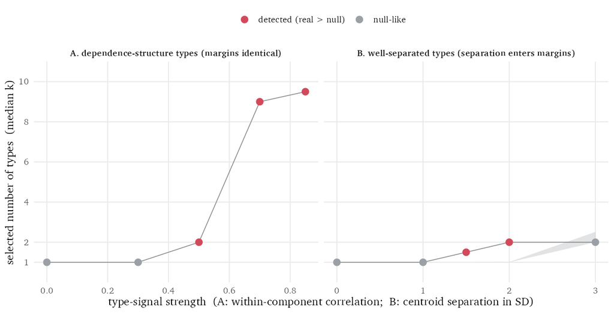

Figure 3: Positive controls on synthetic data with known structure. Grey band: the 95% interval of the matched-null median count. Points: the real median count, red where it exceeds the null. Left: types defined only by dependence (identical margins, opposite correlation orientation) are detected, increasingly so with signal strength. Right: types separated in their means are detected at moderate separation and are reproduced by the null only at the largest separation, where the separation is fully carried by the margins and covariance the null preserves. Personality trait margins carry no such separation, placing these data in the left regime.

## 4.7 Verdict

The preregistered rule (registered as H2) classifies a structure as continuous only if four conditions hold jointly: a mean registered CCFI below .45 with no trait categorical; a confident-assignment share below 50%; a first-split share above 75%; and a median count indistinguishable from the null (H3). A categorical classification requires the converse of each.

# 5 Discussion

This study asked whether the types a mixture model reports in personality data correspond to categories of people or to the continuous shape of the data, and addressed the question with a test rather than an additional clustering. Each dataset was compared to a copula matched null that preserves its margins and covariance; the analysis ran across all fourteen covariance parameterizations; and a taxometric index provided an independent second reading. Across three datasets the selected count ranged from one to ten as a function of the covariance assumption, fell within the typeless null by the registered statistic in every case, and reached the categorical threshold for no trait.

This is primarily a methodological result rather than a substantive one. That trait structure is dimensional rather than categorical is already established (Haslam et al., 2012; Haslam et al., 2020), and the point here is not to add to that case but to give the claim that a dataset contains N types a test, and to show how much of the reported N comes from a modeling choice that says nothing about people.

The pieces are borrowed. The Gaussian copula and the rank construction that builds the twins are standard (Iman & Conover, 1982; Sklar, 1959), and testing a statistic against a null that fixes the innocent features of the data is long used in other fields (Theiler et al., 1992). What no existing test of a cluster count does is hold all three together. The null fixes both the trait distributions and the full correlation matrix, leaving only the dependence beyond them free to form clusters. It is fit under all fourteen ways the mixture model can shape its components, so the count comes out as a range rather than one number. And it is defined on the data, not on a particular clustering method, so a published typology can be run against the twins with its own procedure unchanged. Each existing null relaxes one of these. The independence null (Gerlach et al., 2018) and the gap statistic’s uniform reference (Tibshirani et al., 2001) fix no dependence, so the data’s correlations clear them on their own; the bootstrap likelihood-ratio test (McLachlan, 1987) commits to a parametric family instead of holding the data’s own structure fixed; and SigClust (Liu et al., 2008) asks whether any clustering exists rather than how many, and tests against a single Gaussian, so non-normal but typeless data read as clustered even when no groups exist. Fixing the margins and correlations together, the matched null separates the number of groups from what a typeless dataset of the same shape already produces.

The claim is deliberately narrow. The matched null tests whether a clustering exceeds the linear dependence already present in the data, and on that test the real data do carry structure the null cannot reproduce: every dataset cleared H1. That residual structure does not, however, increase the number of types or produce categorical taxometric curves. The supported conclusion is therefore “no evidence for separated types” rather than “strictly continuous.” Some real departure from joint normality is present in every dataset, below the level of a discrete class, and I do not attempt to characterize it here; skew, mild nonlinearity, or uneven density would each suffice, and none constitutes a kind of person.

The matched null leaves one situation unresolved. Suppose two groups differ only in their average trait levels, and the separation between them is large enough to show in the individual trait distributions and in the correlations among traits. The null preserves both, so its twins reproduce the same separation, and the test reports that the real data cluster no more than the twins do. This is the three-standard-deviation case in the separation controls (Figure 3), where the test does not flag a pair of clearly separated groups.

This follows from a property of the data. Two groups separated that far have a pooled distribution with a certain shape in each trait and a certain set of correlations, and a single group whose traits are skewed or unevenly spread can have the same shape and the same correlations. Given only the distributions and the correlations, which is all the null preserves and all a count works from, the two-group and single-group descriptions cannot be told apart. The information that would separate them is not present in the data.

Reporting the two groups as real therefore requires an assumption the data do not supply: that they come from a mixture of Gaussian components, under which the two-group reading holds by construction. The bootstrap likelihood-ratio test makes that assumption. Committing to Gaussian components, it fits a single skewed group with several of them, and on the skewed but typeless data of the calibration it reports more than one component in every dataset tested, whether or not a second group is present (Table S7).

The analysis also illustrates the problem it addresses. Whether the count exceeds the null depends on whether the per-model counts are summarized by their mean or their median, since a few parameterizations at the ten-component ceiling inflate the mean. The count from any single parameterization is bounded above by the grid ceiling, so the per-model counts are right-censored, and the mean of a right-censored batch is pulled by the ceiling rather than describing the bulk of the parameterizations; I preregistered the median for that reason, and report both; the divergence is itself an instance of the analytic flexibility the method is meant to surface, and a concrete reason to fix such a statistic in advance.

The approach is not specific to personality. Any claim that continuous measurements fall into a given number of groups can be evaluated against a matched null, and reporting the distribution of results across reasonable specifications, rather than a single preferred one, applies wherever a modeling choice is incidental to the question. The matched null also supplies the constructed comparison that earlier critiques of typology research called for but did not provide (Katahira et al., 2020), for which an independence null is insufficient.

Several limitations apply. A multiverse analysis is bounded by the choices it spans; I varied the covariance parameterization exhaustively but held the mixture family, the selection criterion, and the indicator resolution fixed, and a broader specification space could be examined. Because the null fixes only linear dependence, a clustering generated by genuinely nonlinear but still continuous structure registers as real without being categorical, which is consistent with the present results and is the behavior the null is intended to produce. The datasets are large but self-selected, drawn from a single item pool, and subsampled for tractability. HEXACO is the instrument whose count comes closest to the categorical side: its registered median sits at the top of the null interval, and under the ellipsoidal-only summary both HEXACO analyses exceed it. Its taxometric and assignment readings stay dimensional and its hold-out is not naive, so it enters as robustness rather than confirmation. Finally, the analysis tests for separated categories and their number, not for the practical utility of a typology; finding no taxa does not establish that a typology is never a useful shorthand, only that it does not correspond to a discovery of discrete kinds.

The practical implication is straightforward. A number of clusters is not by itself a finding; it becomes one only when it exceeds what the data’s own margins and covariance produce and is stable across choices, such as the covariance parameterization, that should not affect a substantive conclusion. The test is a fixed workflow that any reported typology can be run through:

1. Inspect the margins for pronounced multimodality, the one regime where the null is blind; granular scales are tested after tie-breaking.
2. Draw copula twins of the data (Algorithm 1).
3. Run the identical clustering pipeline, whatever it is, on the real data and on every twin.
4. Compare the real count with the twins’ distribution (H1 and H3).
5. Read the categorical signatures of the selected solution: assignment confidence, first-split share, and, where the indicators allow, the CCFI.

Because the null is defined at the level of the data rather than of any pipeline, a published typology’s own procedure can be run unchanged at step 3. The framework is algorithm-agnostic in principle, and the supplement bears this out in practice: run against the same matched null on the same data, k-means with a gap-statistic count returns the same verdict as the Gaussian mixture, the real count within the null for every dataset, even though the two engines report very different raw counts (Table S8). The implementation is public, so that a future claim of N types can be evaluated for whether N reflects the respondents or the analysis.

# 6 Conclusion

The number of types a method reports is not, by itself, a property of the people it describes. In personality, where dimensional structure is already well established, the selected count varied across the full range as a single inconsequential assumption was changed, remained within the range produced by a typeless null, and showed no categorical signature in any trait. The substantive conclusion is not new; the contribution is the test, which can hold a claim of N types against a meaningful null and quantify how much that claim depends on otherwise unexamined choices. The materials are public, so subsequent claims can be subjected to the same check. Whether a structure is real and whether it constitutes a set of discrete kinds are distinct questions, and a count of clusters answers neither until it is evaluated against an appropriate null.

# Supplementary material

**Table S1.** The number of components BIC selected under each of the fourteen mclust covariance parameterizations, at the matched sample size (8,000 cases for domain analyses, 5,000 for facet analyses). The median of each column is the registered count statistic reported in Table 1.

| Model | NEO-120 dom. | NEO-120 fac. | IPIP-50 dom. | HEXACO dom. | HEXACO fac. |
| --- | --- | --- | --- | --- | --- |
| EII | 10 | 10 | 10 | 10 | 10 |
| VII | 10 | 10 | 10 | 10 | 10 |
| EEI | 10 | 10 | 10 | 10 | 10 |
| VEI | 9 | 10 | 10 | 9 | 10 |
| EVI | 10 | 10 | 10 | 10 | 10 |
| VVI | 10 | 10 | 8 | 10 | 10 |
| EEE | 5 | 2 | 7 | 10 | 5 |
| EVE | 4 | 3 | 7 | 5 | 3 |
| VEE | 5 | 5 | 10 | 4 | 3 |
| VVE | 3 | 3 | 8 | 4 | 2 |
| EEV | 5 | 1 | 6 | 4 | 1 |
| VEV | 2 | 2 | 6 | 2 | 2 |
| EVV | 4 | 1 | 5 | 4 | 1 |
| VVV | 2 | 2 | 6 | 2 | 2 |
| **Median** | **5** | **4** | **8** | **7** | **4** |

**Table S2.** Comparison Curve Fit Index for each trait under MAMBAC and MAXEIG (the two preregistered procedures), their mean (the registered statistic, plotted in Figure 2), and the supplementary L-Mode curve. Values below .45 indicate dimensional structure, above .55 categorical, ambiguous between.

| Trait | MAMBAC | MAXEIG | Mean (registered) | L-Mode |
| --- | --- | --- | --- | --- |
| NEO-120 Neuroticism | .281 | .301 | .291 | .316 |
| NEO-120 Extraversion | .450 | .346 | .398 | .385 |
| NEO-120 Openness | .644 | .425 | .535 | .364 |
| NEO-120 Agreeableness | .548 | .311 | .430 | .491 |
| NEO-120 Conscientiousness | .185 | .253 | .219 | .391 |
| HEXACO Honesty-Humility | .537 | .504 | .520 | .541 |
| HEXACO Emotionality | .390 | .540 | .465 | .559 |
| HEXACO eXtraversion | .373 | .268 | .321 | .344 |
| HEXACO Agreeableness | .385 | .564 | .475 | .471 |
| HEXACO Conscientiousness | .240 | .562 | .401 | .542 |
| HEXACO Openness | .302 | .496 | .399 | .546 |

**Table S3.** Sensitivity of the count test to the covariance family: the median selected count computed over the eight fully ellipsoidal parameterizations only, for the real data and for the matched null (95% interval of the null’s ellipsoid-only median, 200 replicates). Two confirmatory analyses sit at the null’s upper boundary; both HEXACO analyses exceed it.

| Slice | Real ellipsoid-only median | Null 95% interval | Within |
| --- | --- | --- | --- |
| NEO-120 dom. | 4.0 | [2.50, 4.00] | yes, at boundary |
| NEO-120 fac. | 2.0 | [1.50, 2.50] | yes |
| IPIP-50 dom. | 6.5 | [3.99, 6.50] | yes, at boundary |
| HEXACO dom. | 4.0 | [2.00, 3.01] | no, exceeds |
| HEXACO fac. | 2.0 | [1.00, 1.50] | no, exceeds |

| Model | NEO-120 dom. | NEO-120 fac. | IPIP-50 dom. | HEXACO dom. | HEXACO fac. |
| --- | --- | --- | --- | --- | --- |
| EII | 2 | 10 | 1 | 3 | 10 |
| VII | 2 | 10 | 1 | 1 | 10 |
| EEI | 2 | 10 | 1 | 1 | 10 |
| VEI | 2 | 10 | 1 | 1 | 10 |
| EVI | 2 | 10 | 1 | 1 | 10 |
| VVI | 2 | 10 | 1 | 1 | 10 |
| EEE | 1 | 1 | 1 | 1 | 1 |
| EVE | 1 | 1 | 1 | 1 | 1 |
| VEE | 1 | 2 | 1 | 1 | 2 |
| VVE | 1 | 2 | 1 | 1 | 2 |
| EEV | 1 | 1 | 1 | 1 | 1 |
| VEV | 1 | 2 | 1 | 1 | 1 |
| EVV | 1 | 1 | 1 | 1 | 1 |
| VVV | 1 | 2 | 1 | 1 | 1 |
| **Median** | **1** | **2** | **1** | **1** | **2** |

**Table S5.** Competing referees on the positive-control data of Figure 3. Truth is the generating number of components. Matched null: whether the registered count test fires (real median above the nulls’ 97.5th percentile). gap: the number selected by the gap statistic (k-means base, fifty reference draws). bLRT: the number selected by the bootstrap likelihood-ratio test under the correctly specified VVV family (99 draws, sequential tests at .05). BIC: the number selected by the BIC envelope over the fourteen parameterizations. The gap statistic never detects the dependence-defined types; the bootstrap test recovers them where its parametric family is exactly right; the matched-null test detects them from moderate signal and, as registered, goes quiet at 3 SD, its stated boundary.

| Panel | Signal | Truth | Matched null | gap | bLRT | BIC |
| --- | --- | --- | --- | --- | --- | --- |
| A (dependence) | 0 | 1 | quiet | 1 | 1 | 1 |
| A (dependence) | .30 | 2 | quiet | 1 | 1 | 1 |
| A (dependence) | .50 | 2 | detected | 1 | 2 | 2 |
| A (dependence) | .70 | 2 | detected | 1 | 2 | 2 |
| A (dependence) | .85 | 2 | detected | 1 | 2 | 2 |
| B (separation) | 0 | 1 | quiet | 1 | 1 | 1 |
| B (separation) | 1.0 | 2 | quiet | 1 | 2 | 2 |
| B (separation) | 1.5 | 2 | detected | 2 | 2 | 2 |
| B (separation) | 2.0 | 2 | detected | 2 | 2 | 2 |
| B (separation) | 3.0 | 2 | quiet | 2 | 2 | 2 |

**Table S6.** The median selected count as a function of subsample size, domain level (fourteen-model grid, held-out data). The HEXACO column at its largest size uses the full hold-out (n = 11,367). The count is a function of n, which is why every comparison in the paper matches the null to the real data’s sample size.

| Slice | n = 2,000 | n = 8,000 | n = 32,000 |
| --- | --- | --- | --- |
| NEO-120 dom. | 2.5 | 5.0 | 10.0 |
| IPIP-50 dom. | 5.0 | 8.0 | 10.0 |
| HEXACO dom. | 2.0 | 7.0 | 7.5 |

**Table S7.** False-positive calibration on typeless data: 100 datasets per scenario, n = 2,000, five variables, correlation matrix taken from the real NEO-120 domains; forty copula nulls per dataset; the test fires when the real fourteen-model median exceeds the nulls’ 97.5th percentile (nominal rate 2.5%). The skewed scenario transforms the margins (chi-square, beta, squared-uniform) while keeping the Gaussian copula: no types exist, but the data are non-normal, the over-extraction regime of Bauer and Curran (2003). The bootstrap LRT was run on the first thirty datasets of each scenario.

| Scenario | Matched-null test fired | BIC selects k > 1 | Mean BIC k | gap selects k > 1 | bLRT selects k > 1 |
| --- | --- | --- | --- | --- | --- |
| Gaussian, typeless | 0% | 0% | 1.0 | 1% | 0% (0/30) |
| Skewed margins, typeless | 0% | 100% | 9.7 | 1% | 100% (30/30) |

**Table S8.** The count test under a second clustering engine. Because the matched null is defined on the data, any clustering pipeline can be run against it. Each held-out domain dataset was tested with two engines of different paradigm and count rule: a Gaussian mixture (the median selected components over the fourteen covariance models, by BIC; the registered engine) and k-means (the number of clusters chosen by the gap statistic), each compared to its own copula matched null at n = 8,000. Both place the real count within the null for every dataset, though the two engines report very different counts. The Gaussian-mixture column is the registered result (Table 1; 200 null replicates); the k-means arm is a robustness demonstration, not a registered analysis, computed with 40 null replicates on an independently drawn subsample of the same size. The comparison is qualitative, each engine’s real count against its own null rather than a match of counts across engines, and the k-means real count of one falls well below the upper bound of its null, so the smaller replicate count and the independent subsample do not bear on the verdict.

| Dataset | Gaussian mixture: real (null 95%) | k-means: real (null 95%) |
| --- | --- | --- |
| NEO-120 dom. | 5 ([4.0, 7.0]) | 1 ([1.0, 2.0]) |
| IPIP-50 dom. | 8 ([6.0, 9.0]) | 1 ([1.0, 2.0]) |
| HEXACO dom. | 7 ([3.5, 7.5]) | 1 ([1.0, 2.0]) |

# References

Asendorpf, J. B., Borkenau, P., Ostendorf, F., & Aken, M. A. G. van. (2001). Carving personality description at its joints: Confirmation of three replicable personality prototypes for both children and adults. *European Journal of Personality*, *15*(3), 169–198. https://doi.org/10.1002/per.408

Bauer, D. J., & Curran, P. J. (2003). Distributional assumptions of growth mixture models: Implications for overextraction of latent trajectory classes. *Psychological Methods*, *8*(3), 338–363. https://doi.org/10.1037/1082-989X.8.3.338

Gerlach, M., Farb, B., Revelle, W., & Nunes Amaral, L. A. (2018). A robust data-driven approach identifies four personality types across four large data sets. *Nature Human Behaviour*, *2*(10), 735–742. https://doi.org/10.1038/s41562-018-0419-z

Goldberg, L. R. (1999). A broad-bandwidth, public domain, personality inventory measuring the lower-level facets of several five-factor models. In I. Mervielde, I. Deary, F. De Fruyt, & F. Ostendorf (Eds.), *Personality psychology in Europe* (Vol. 7, pp. 7–28). Tilburg University Press.

Hartigan, J. A., & Hartigan, P. M. (1985). The dip test of unimodality. *Annals of Statistics*, *13*(1), 70–84. https://doi.org/10.1214/aos/1176346577

Haslam, N., Holland, E., & Kuppens, P. (2012). Categories versus dimensions in personality and psychopathology: A quantitative review of taxometric research. *Psychological Medicine*, *42*(5), 903–920. https://doi.org/10.1017/S0033291711001966

Haslam, N., McGrath, M. J., Viechtbauer, W., & Kuppens, P. (2020). Dimensions over categories: A meta-analysis of taxometric research. *Psychological Medicine*, *50*(9), 1418–1432. https://doi.org/10.1017/S003329172000183X

Hennig, C. (2010). Methods for merging Gaussian mixture components. *Advances in Data Analysis and Classification*, *4*(1), 3–34. https://doi.org/10.1007/s11634-010-0058-3

Iman, R. L., & Conover, W. J. (1982). A distribution-free approach to inducing rank correlation among input variables. *Communications in Statistics—Simulation and Computation*, *11*(3), 311–334. https://doi.org/10.1080/03610918208812265

Johnson, J. A. (2014). Measuring thirty facets of the five factor model with a 120-item public domain inventory: Development of the IPIP-NEO-120. *Journal of Research in Personality*, *51*, 78–89. https://doi.org/10.1016/j.jrp.2014.05.003

Katahira, K., Kunisato, Y., Yamashita, Y., & Suzuki, S. (2020). Commentary: A robust data-driven approach identifies four personality types across four large data sets. *Frontiers in Big Data*, *3*, 8. https://doi.org/10.3389/fdata.2020.00008

Leamer, E. E. (1983). Let’s take the con out of econometrics. *American Economic Review*, *73*(1), 31–43.

Lee, K., & Ashton, M. C. (2004). Psychometric properties of the HEXACO personality inventory. *Multivariate Behavioral Research*, *39*(2), 329–358. https://doi.org/10.1207/s15327906mbr3902_8

Liu, Y., Hayes, D. N., Nobel, A., & Marron, J. S. (2008). Statistical significance of clustering for high-dimension, low-sample-size data. *Journal of the American Statistical Association*, *103*(483), 1281–1293. https://doi.org/10.1198/016214508000000454

McLachlan, G. J. (1987). On bootstrapping the likelihood ratio test statistic for the number of components in a normal mixture. *Journal of the Royal Statistical Society: Series C (Applied Statistics)*, *36*(3), 318–324. https://doi.org/10.2307/2347790

Meehl, P. E. (1995). Bootstraps taxometrics: Solving the classification problem in psychopathology. *American Psychologist*, *50*(4), 266–275. https://doi.org/10.1037/0003-066X.50.4.266

R Core Team. (2025). *R: A language and environment for statistical computing*. R Foundation for Statistical Computing. https://www.R-project.org/

Raftery, A. E. (1995). Bayesian model selection in social research. *Sociological Methodology*, *25*, 111–163. https://doi.org/10.2307/271063

Robins, R. W., John, O. P., Caspi, A., Moffitt, T. E., & Stouthamer-Loeber, M. (1996). Resilient, overcontrolled, and undercontrolled boys: Three replicable personality types. *Journal of Personality and Social Psychology*, *70*(1), 157–171. https://doi.org/10.1037/0022-3514.70.1.157

Ruscio, J. (2023). *RTaxometrics: Taxometric analysis* (Version 3.2.1) [Computer software]. https://CRAN.R-project.org/package=RTaxometrics

Ruscio, J., Haslam, N., & Ruscio, A. M. (2006). *Introduction to the taxometric method: A practical guide*. Lawrence Erlbaum Associates.

Schreiber, T., & Schmitz, A. (2000). Surrogate time series. *Physica D: Nonlinear Phenomena*, *142*(3–4), 346–382. https://doi.org/10.1016/S0167-2789(00)00043-9

Scrucca, L., Fop, M., Murphy, T. B., & Raftery, A. E. (2016). Mclust 5: Clustering, classification and density estimation using Gaussian finite mixture models. *The R Journal*, *8*(1), 289–317. https://doi.org/10.32614/RJ-2016-021

Simonsohn, U., Simmons, J. P., & Nelson, L. D. (2020). Specification curve analysis. *Nature Human Behaviour*, *4*(11), 1208–1214. https://doi.org/10.1038/s41562-020-0912-z

Sklar, A. (1959). Fonctions de répartition à $n$ dimensions et leurs marges. *Publications de l’Institut de Statistique de l’Université de Paris*, *8*, 229–231.

Steegen, S., Tuerlinckx, F., Gelman, A., & Vanpaemel, W. (2016). Increasing transparency through a multiverse analysis. *Perspectives on Psychological Science*, *11*(5), 702–712. https://doi.org/10.1177/1745691616658637

Theiler, J., Eubank, S., Longtin, A., Galdrikian, B., & Farmer, J. D. (1992). Testing for nonlinearity in time series: The method of surrogate data. *Physica D: Nonlinear Phenomena*, *58*(1–4), 77–94. https://doi.org/10.1016/0167-2789(92)90102-S

Tibshirani, R., Walther, G., & Hastie, T. (2001). Estimating the number of clusters in a data set via the gap statistic. *Journal of the Royal Statistical Society: Series B*, *63*(2), 411–423. https://doi.org/10.1111/1467-9868.00293

## Footnotes

[^1]: A *taxon* (plural *taxa*; from Greek *táxis*, “arrangement”) is the term of art in taxometrics (Meehl, 1995; Ruscio et al., 2006) for a genuine latent category, a discrete kind of person as opposed to a position on a continuum. The title’s contrast is between *types* that a clustering method reports as output and *taxa* that would have to exist in the population for those types to refer to anything real.
[^2]: The surrogate-data method comes from nonlinear time-series analysis (Schreiber & Schmitz, 2000; Theiler et al., 1992): fix the innocent features of a signal, here the margins and the linear covariance, randomize only the feature under test, and ask whether the real statistic exceeds its surrogate distribution. The Gaussian-copula null carries that logic to a mixture-model count.
[^3]: The three-letter codes name how each component’s covariance is held in volume, shape, and orientation: E for equal across components, V for varying, I for the identity (a spherical or axis-aligned shape). EII is equal-volume spherical; VVV lets volume, shape, and orientation all vary freely (Scrucca et al., 2016).
[^4]: The term *copula* (Latin *copula*, “tie, link,” the root of English *couple*) is borrowed in statistics from Sklar (1959), where it denotes the function that ties a set of one-variable marginals into a joint distribution, separately from the marginals themselves. Any multivariate distribution decomposes uniquely into its marginals and a copula; the *Gaussian* copula is the one whose dependence is fixed entirely by a correlation matrix, with no further joint structure.
[^5]: By the conventional reading a $\Delta$BIC above 10 is very strong evidence for the better-fitting model (Raftery, 1995). The test here does not lean on that convention: it compares the real $\Delta$BIC to the null’s own distribution rather than to a fixed cutoff.
[^6]: MAMBAC (Mean Above Minus Below A Cut) slides a cut along one indicator and plots the mean difference on another; MAXEIG (Maximum Eigenvalue) tracks the largest eigenvalue of the indicators across ordered subsamples. A genuine category bows these curves into a characteristic peak, while continuous data leave them flat (Ruscio et al., 2006).